# Выполнение 11 лабораторной работы

Текстовой редактор emacs

Павлюченков С.В.

Российский университет дружбы народов, Москва, Россия

07 сентября 2024

## Докладчик

- Павлюченков Сергей Витальевич
- Студент ФФМиЕН
- Российский университет дружбы народов
- 1132237372@pfur.ru
- https://serapshi.github.io/svpavliuchenkov.github.io/

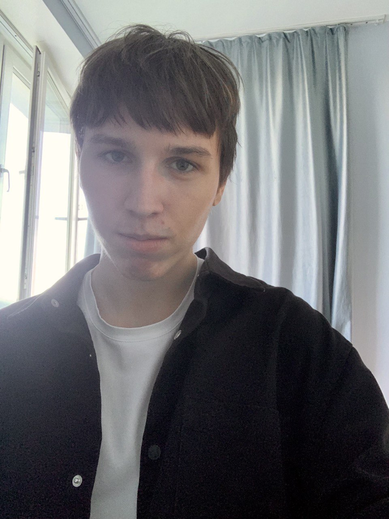

## Цель работы

Познакомиться с операционной системой Linux. Получить практические навыки работы с редактором Emacs.

## Задание

1. Ознакомиться с теоретическим материалом.
2. Ознакомиться с редактором emacs.
3. Выполнить упражнения.
4. Ответить на контрольные вопросы.

# Выполнение лабораторной работы

## Запуск emacs.

[figure not shown]

Запуска программы

## Создание файла

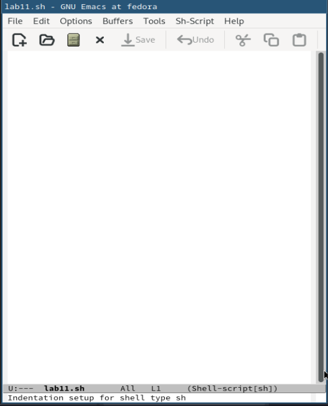

Создание пустого файла

## Работа со строками

После того, как наберал текст вырезаю одной командой целую строку (С-k).

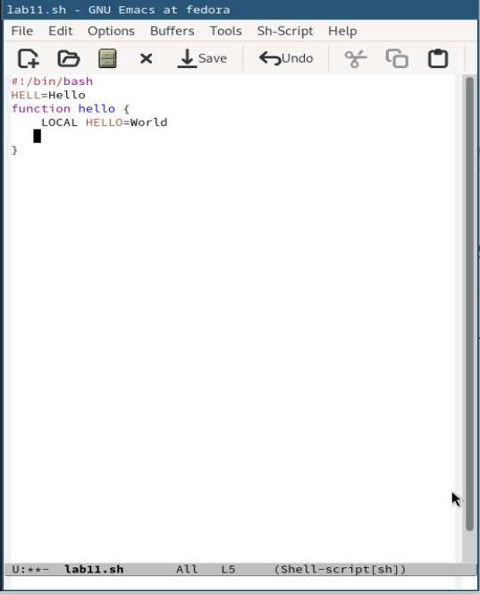

Работа со стандартными процедурами редактирования

## Работа со строками

Вставить эту строку в конец файла (C-y).

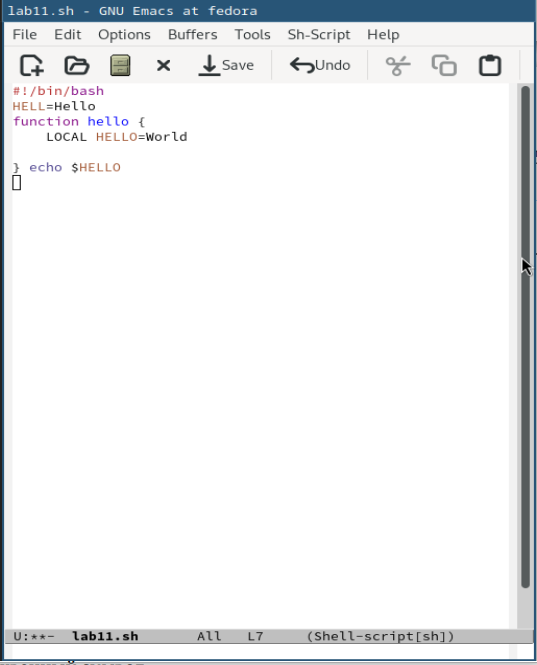

Работа со стандартными процедурами редактирования

## Выделение области текста (C-space).

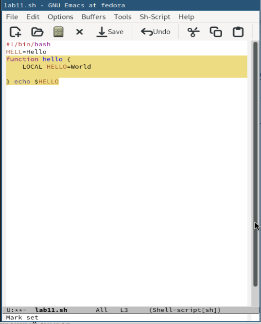

Работа со стандартными процедурами редактирования

## Скопирование области в буфер обмена (M-w).

Вставил область в конец файла.

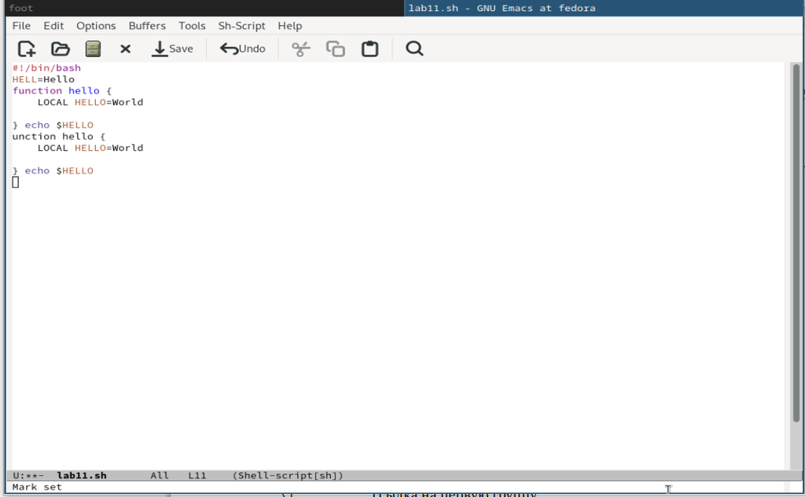

Работа со стандартными процедурами редактирования

## Выделение области и вырезание её (C-w).

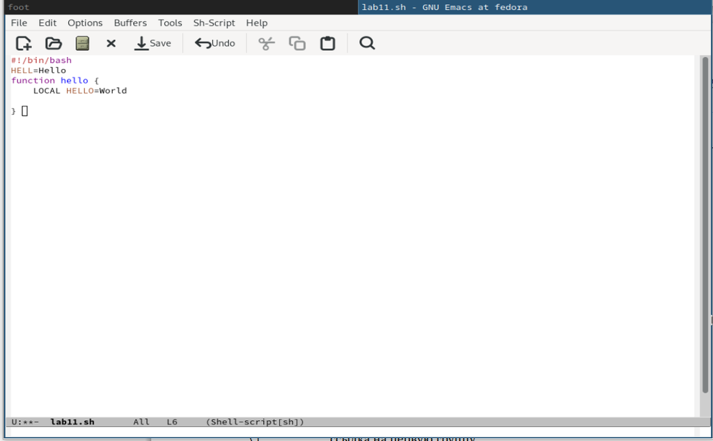

Работа со стандартными процедурами редактирования

## Отмена последнего действия (C-/).

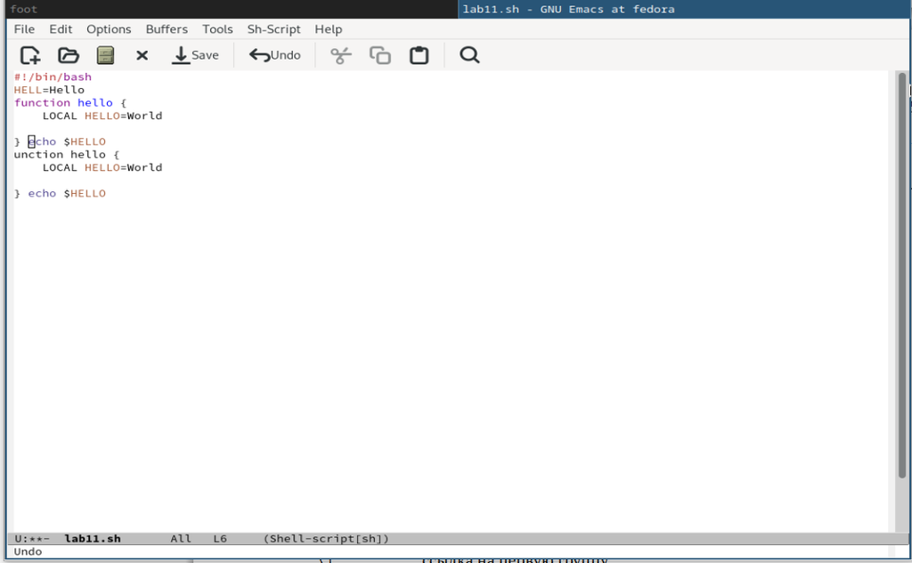

Работа со стандартными процедурами редактирования

## Перемещение курсора в начало строки (C-a).

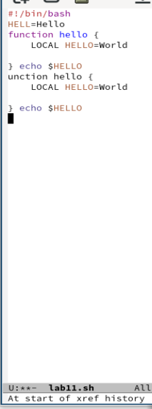

Работа с строкой

## Перемещение курсора в конец буфера (M->).

[figure not shown]

Работа с буфером

## Вывод списка активных буферов на экран (C-x C-b).

[figure not shown]

Работа с буфером

## Перемещение в открытое окно (C-x) o со списком открытых буферов и переключение на другой буфер.

[figure not shown]

Работа с буфером

## Закрытие окна (C-x 0). Переключаение между буферами, но уже без вывода их списка на экран (C-x b).

[figure not shown]

Работа с буфером

## Деление фрейма на 4 части:

Разделил фрейм на два окна по вертикали (C-x 3), а затем каждое из этих окон на две части по горизонтали (C-x 2)

[figure not shown]

Работа с буфером

## Работа с фреймами

В каждом из четырёх созданных окон открыл новый буфер (файл) и ввел несколько строк текста.

[figure not shown]

Работа с буфером

## Режим поиска

Переключился в режим поиска (C-s) и нашел несколько слов, присутствующих в тексте.

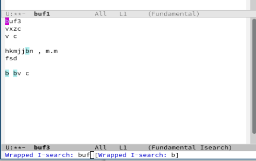

Режим поиска

## Режим поиска

Переключаюсь между результатами поиска, нажимая C-s.

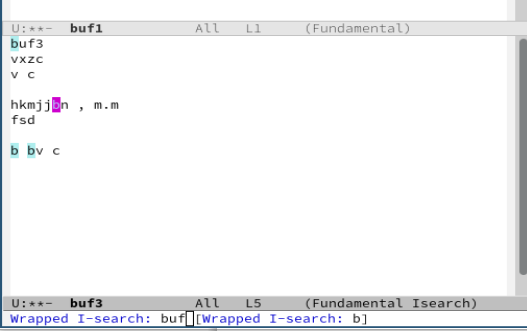

Режим поиска

## Режим поиска

Перешел в режим поиска и замены (M-%), ввел текст, который следует найти и заменить, нажал Enter , затем ввел текст для замены.

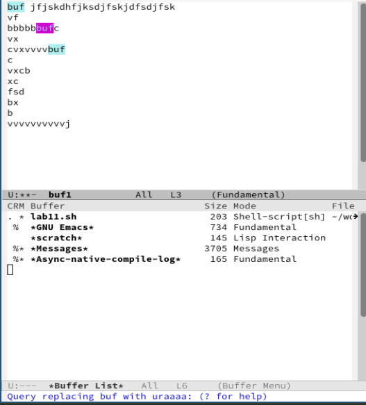

Режим поиска

## Режим замены

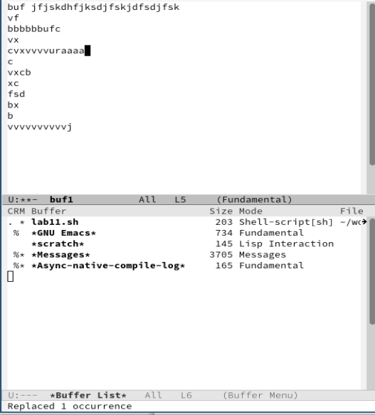

Режим поиска

## Режим поиска

Другой способ выводит результат поиска подробнее.

[figure not shown]

Режим поиска

## Выводы

Я научился работать с emacs, буфером и встроенным режимом поиска и замены.